# Publication Figure 3

# Libraries

Standard Import

```r
library(tidyverse)
library(cowplot)
library(scales)
library(ggpubr)
```

Special

```r
library(ggridges)
library(grid)
# library(Hmisc)
# library(ggExtra)
```

# Paths

```r
bin_dir = '../bin/'
data_dir = '../data/'
results_dir = '../results/'
```

# Custom Scripts / Theme

```r
source(paste0(bin_dir, 'theme_settings.R'))
source (paste0(bin_dir, 'utilities.R'))
source(paste0(bin_dir, 'species_competition_functions.R'))
source(paste0(bin_dir, 'distmat_utils.R'))
source(paste0(bin_dir, 'analysis_metadata.R'))
date <- format(Sys.time(), "%d%m%y")
```

# Import Tables

Metadata

```r
samples.metadata <- read_tsv(paste0(data_dir, 'samples.metadata.tsv'))
microbe.taxonomy <- read_tsv(paste0(data_dir, 'microbe.taxonomy.tsv'))
microbe.metadata <- microbe.taxonomy %>%
  right_join(., read_tsv(paste0(data_dir, 'microbe.metadata.tsv')))
```

## Taxonomy

MetaPhlAn2 tables combine with taxonomy

```r
mp_species.long <- microbe.taxonomy %>%
  right_join(., read_tsv(paste0(data_dir, 'samples.mp_profiles.species.tsv')),
             by = 'species') %>%
  left_join(., samples.metadata, by = 'Name')
```

rCDI subset annotate with metadata

```r
mp_species.rcdi.long <-
  mp_species.long %>%
  filter(Study %in% c(rcdi.studies))
```

## SameStr Data

SameStr Case-Summary table

```r
samples.sstr_data <- read_tsv(paste0(data_dir, 'samples.sstr_data_wmetadata.tsv')) %>%
  left_join(., microbe.taxonomy, by = 'species')
```

## Strain Finder Data

Strain Finder Tables

```r
sf_strain_table <- read_tsv(paste0(data_dir, 'ALM.Strain_Table.tsv')) %>%
  rename(Sample = 'X1')
sf_species_table <- read_tsv(paste0(data_dir, 'ALM.MG_OTU_Bacteria.tsv')) %>%
  rename(bact = `BACT ID`) %>%
  rename_all(.funs = funs(str_to_lower(.)))
```

## Mock Data

Multi-Strain Species Population

```r
mock.sstr_data <- read_tsv(paste0(data_dir, 'mock.sstr_data_wmetadata.tsv')) %>%
  left_join(., microbe.taxonomy, by = 'species')
```

## Fast ANI

FastAni Comparison Data

```r
refs <- read_tsv(paste0(data_dir, 'references.mp_fastani.tsv'))
```

# Set Figure

```r
fig = paste0('Fig_3.')
```

# Specificity of Shared Taxa

Comparing distributions of shared (genera, species, and) strains in related and unrelated sample pairs in order to assess the specificity with which methods call shared strains.

## Strain Finder

### Format

Taxa per sample matrix

```r
# mg-OTU strain-level matrix
sf_strain_table.matrix <-
  sf_strain_table %>%
  mutate_at(.vars = vars(everything(), -Sample),
            .funs = funs(as.numeric(. > 0))) %>%
  column_to_rownames('Sample') %>%
  as.matrix()

colnames(sf_strain_table.matrix) <-
  tibble(tax = colnames(sf_strain_table.matrix)) %>%
  separate(col = tax, into = c('bact', 'gdna'), sep = ';') %>%
  group_by(bact) %>%
  mutate(strain_id = paste0(bact, '.', dense_rank(gdna))) %>%
  pull(strain_id)

# mg-OTU species-level matrix
sf_species_table.matrix <-
  sf_strain_table %>%
  mutate_at(.vars = vars(everything(), -Sample),
            .funs = funs(as.numeric(. > 0))) %>%
  pivot_longer(names_to = 'tax', values_to = 'rel_abund', cols = starts_with('BACT')) %>%
  separate(col = tax, into = c('bact', 'gdna'), sep = ';') %>%
  select(-gdna) %>%
  group_by(Sample, bact) %>%
  summarize(rel_abund = as.numeric(sum(rel_abund, na.rm = T) > 0), .groups = 'drop') %>%
  pivot_wider(id_cols = 'Sample', names_from = 'bact', values_from = 'rel_abund') %>%
  column_to_rownames('Sample') %>%
  as.matrix()

# mg-OTU genus-level matrix
sf_genus_table.matrix <-
  sf_strain_table %>%
  mutate_at(.vars = vars(everything(), -Sample),
            .funs = funs(as.numeric(. > 0))) %>%
  pivot_longer(names_to = 'tax', values_to = 'rel_abund', cols = starts_with('BACT')) %>%
  separate(col = tax, into = c('bact', 'gdna'), sep = ';') %>%
  select(-gdna) %>%
  group_by(Sample, bact) %>%
  summarize(rel_abund = as.numeric(sum(rel_abund, na.rm = T) > 0), .groups = 'drop') %>%
  left_join(., sf_species_table %>% select(bact, genus), by = 'bact') %>%
  group_by(Sample, genus) %>%
  summarize(rel_abund = as.numeric(sum(rel_abund, na.rm = T) > 0), .groups = 'drop') %>%
  pivot_wider(id_cols = 'Sample', names_from = 'genus', values_from = 'rel_abund') %>%
  column_to_rownames('Sample') %>%
  as.matrix()
```

Sample/Sample co-occurrence matrix at mg-OTU species- and strain-level

```r
# genus
sf_genus_table.dist <- sf_genus_table.matrix %*% t(sf_genus_table.matrix)
sf_genus_table.long <-
  distmat_to_long(distmat = as.data.frame(sf_genus_table.dist),
                  value_name = 'n.shared_genus',
                  rm_diag = T)
sf_genus_counts <- diag(sf_genus_table.dist) %>%
  as.data.frame() %>%
  rownames_to_column('Sample') %>%
  rename(n.genus = '.')

# species
sf_species_table.dist <- sf_species_table.matrix %*% t(sf_species_table.matrix)
sf_species_table.long <-
  distmat_to_long(distmat = as.data.frame(sf_species_table.dist),
                  value_name = 'n.shared_species',
                  rm_diag = T)
sf_species_counts <- diag(sf_species_table.dist) %>%
  as.data.frame() %>%
  rownames_to_column('Sample') %>%
  rename(n.species = '.')

# strain
sf_strain_table.dist <- sf_strain_table.matrix %*% t(sf_strain_table.matrix)
sf_strain_table.long <-
  distmat_to_long(distmat = as.data.frame(sf_strain_table.dist),
                  value_name = 'n.shared_strains',
                  rm_diag = T)
sf_strain_counts <- diag(sf_strain_table.dist) %>%
  as.data.frame() %>%
  rownames_to_column('Sample') %>%
  rename(n.strains = '.')
```

join data

```r
sf <-
  full_join(sf_species_table.long, sf_strain_table.long, by = c('row','col')) %>%
  full_join(., sf_genus_table.long, by = c('row','col')) %>%

  left_join(., sf_genus_counts, by = c('row' = 'Sample')) %>%
  left_join(., sf_genus_counts, by = c('col' = 'Sample'), suffix = c('.row', '.col')) %>%

  left_join(., sf_species_counts, by = c('row' = 'Sample')) %>%
  left_join(., sf_species_counts, by = c('col' = 'Sample'), suffix = c('.row', '.col')) %>%

  left_join(., sf_strain_counts, by = c('row' = 'Sample')) %>%
  left_join(., sf_strain_counts, by = c('col' = 'Sample'), suffix = c('.row', '.col')) %>%

  rename(Sample.row = row,
         Sample.col = col,
         n.shared_species.sf = n.shared_species,
         n.shared_strains.sf = n.shared_strains,
         n.shared_genus.sf = n.shared_genus) %>%

  rename_at(.vars = vars(matches('n.*col'), matches('n.*row')),
            .funs = funs(gsub(gsub(., pattern = '.row', replacement = '.sf.row'),
                              pattern = '.col', replacement = '.sf.col'))) %>%
  left_join(., samples.metadata, by = c('Sample.row' = 'Sample')) %>%
  left_join(., samples.metadata, by = c('Sample.col' = 'Sample'), suffix = c('.row', '.col')) %>%
  filter(!is.na(Name.row), !is.na(Name.col)) %>%
  rowwise() %>%
  mutate(Name.paste = paste0(sort(c(Name.row, Name.col)), collapse = ',')) %>%
  ungroup() %>%
  mutate(n.not_shared_strains.sf = (n.strains.sf.row - n.shared_strains.sf) + (n.strains.sf.col - n.shared_strains.sf),
         n.not_shared_species.sf = (n.species.sf.row - n.shared_species.sf) + (n.species.sf.col - n.shared_species.sf),
         n.not_shared_genus.sf = (n.genus.sf.row - n.shared_genus.sf) + (n.genus.sf.col - n.shared_genus.sf),
         n.total_strains.sf = n.shared_strains.sf + n.not_shared_strains.sf,
         n.total_species.sf = n.shared_species.sf + n.not_shared_species.sf,
         n.total_genus.sf = n.shared_genus.sf + n.not_shared_genus.sf,
         f.shared_strains.sf = n.shared_strains.sf / n.total_strains.sf,
         f.shared_species.sf = n.shared_species.sf / n.total_species.sf,
         f.shared_genus.sf = n.shared_genus.sf / n.total_genus.sf)
```

### Shared Taxa

Density Ridge Plot based on Strain Finder Data published with the Alm dataset, showing co-occurrence of genera, species, and strains in samples which are common in unrelated but more common in related samples.

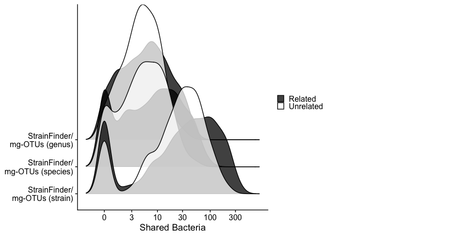

```r
sf %>%
  mutate(related = ifelse(replace_na(Donor.Subject.row == Donor.Subject.col, F), 'Related', 'Unrelated')) %>%
  pivot_longer(names_to = 'metric', values_to = 'value',
               cols = c('n.shared_genus.sf', 'n.shared_species.sf', 'n.shared_strains.sf')) %>%
  mutate(metric = case_when(
         metric == 'n.shared_strains.sf' ~ 'StrainFinder/\nmg-OTUs (strain)',
         metric == 'n.shared_species.sf' ~ 'StrainFinder/\nmg-OTUs (species)',
         metric == 'n.shared_genus.sf' ~ 'StrainFinder/\nmg-OTUs (genus)',
         T ~ metric
       )) %>%
ggplot(aes(value, fct_relevel(metric,
                              'StrainFinder/\nmg-OTUs (strain)',
                              'StrainFinder/\nmg-OTUs (species)',
                              'StrainFinder/\nmg-OTUs (genus)'), fill = related)) +
  geom_density_ridges(panel_scaling = F, alpha = 0.75, scale = 5) +
  scale_fill_manual(values = c('black','white')) +
  scale_x_continuous(trans = pseudo_log_trans(), breaks = c(0, 3, 10, 30, 100, 300)) +
  theme_cowplot() +
  labs(x = 'Shared Bacteria') +
  theme(legend.key.size = unit(c(.75, .5, .75, .5), "lines"),
        legend.title = element_blank(),
        axis.title.y = element_blank(),
        )
```

## SameStr

### Format

Generate MetaPhlAn co-occurrence table, taxa counts

```r
cooccurrence <- mp_cooccurrence(mp_species.long)
taxa_counts <- cooccurrence$mp_taxa_counts
taxa_cooccurrence <- cooccurrence$mp_taxa_table.long
```

Merge with SameStr strain-level data

```r
sstr <-
  samples.sstr_data %>%

  group_by(Study.pair, Name.row, Name.col,
           Case_Name.pair, Case_Name.row, Case_Name.col, Same_Case.label,
           Related.label, Related.bool, Pair_Type) %>%
  summarize(.groups = 'drop',
            n.analyzed_strains = sum(overlap > min_overlap, na.rm = T),
            n.shared_strains.mvs = sum(distance.mvs > min_similarity & overlap > min_overlap, na.rm = T),
            n.shared_strains.cvs = sum(distance.cvs > min_similarity & overlap > min_overlap, na.rm = T)) %>%

  # tag successful fmt cases
  mutate(fmt_success = !Case_Name.pair %in% cases_failed) %>%
  mutate(Study.row = str_split_fixed(Name.row, pattern = '_', 2)[,1],
         Study.col = str_split_fixed(Name.col, pattern = '_', 2)[,1]) %>%
  mutate(Related.text = ifelse(Related.bool, 'Related', 'Unrelated')) %>%

  rowwise() %>%
  mutate(Sample_Pair = paste0(sort(c(Name.row, Name.col)), collapse = ',')) %>%
  ungroup() %>%
  left_join(., taxa_cooccurrence, by = 'Sample_Pair') %>%
  left_join(., taxa_counts, by = c('Name.row' = 'Sample')) %>%
  left_join(., taxa_counts, by = c('Name.row' = 'Sample'), suffix = c('.row','.col')) %>%

  mutate(n.not_shared_species = (n.species.row - n.shared_species) + (n.species.col - n.shared_species),
         n.not_shared_genus = (n.genus.row - n.shared_genus) + (n.genus.col - n.shared_genus),
         n.not_shared_family = (n.family.row - n.shared_family) + (n.family.col - n.shared_family),

         n.total_species = n.shared_species + n.not_shared_species,
         n.total_genus = n.shared_genus + n.not_shared_genus,
         n.total_family = n.shared_family + n.not_shared_family,

         f.shared_strains.mvs = replace_na(n.shared_strains.mvs / n.analyzed_strains, 0),
         f.shared_strains.cvs = replace_na(n.shared_strains.cvs / n.analyzed_strains, 0),
         f.shared_species = n.shared_species / n.total_species,
         f.shared_genus = n.shared_genus / n.total_genus,
         f.shared_family = n.shared_family / n.total_family)
```

Subset rCDI Alm data

```r
sstr.alm <-
  sstr %>%
  # ALM only, same as above
  filter(Study.pair == 'ALM')

sstr.control <-
  sstr %>%
  # Control only
  filter(Study.row %in% control.studies &
         Study.col %in% control.studies) %>%
  mutate(Related.text = ifelse(Related.bool, 'Related', 'Unrelated'))
```

### Shared Taxa

Density Ridge Plot based on SameStr Data for the same Alm dataset shown above, showing co-occurrence of genera, species, and strains in samples. Co-occurrence is common in unrelated genera and species, but more separable compared to SF. For shared strains, distributions divide related from unrelated sample pairs which mostly don’t share any strains.

#### Alm

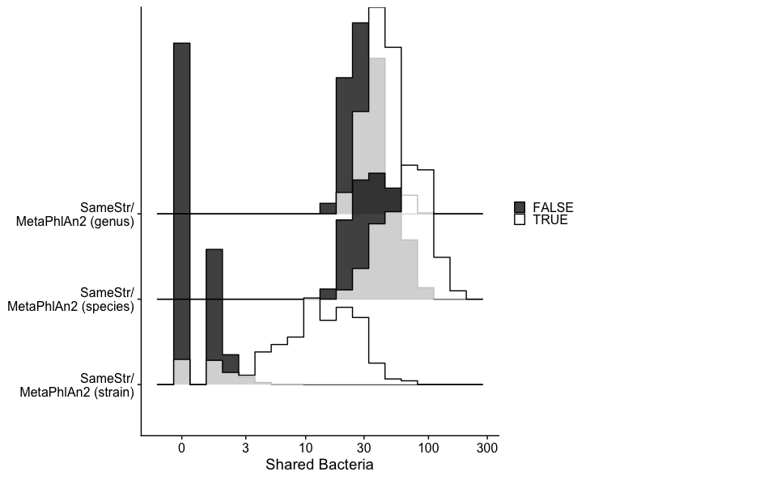

```r
sstr.alm %>%

  pivot_longer(names_to = 'metric', values_to = 'value',
               cols = c('n.shared_genus', 'n.shared_species', 'n.shared_strains.mvs')) %>%
  mutate(metric = case_when(
         metric == 'n.shared_strains.mvs' ~ 'SameStr/\nMetaPhlAn2 (strain)',
         metric == 'n.shared_species' ~ 'SameStr/\nMetaPhlAn2 (species)',
         metric == 'n.shared_genus' ~ 'SameStr/\nMetaPhlAn2 (genus)',
         T ~ metric
       )) %>%
ggplot(aes(value, fct_relevel(metric,
                              'SameStr/\nMetaPhlAn2 (strain)',
                              'SameStr/\nMetaPhlAn2 (species)',
                              'SameStr/\nMetaPhlAn2 (genus)',), fill = Related.bool)) +
  geom_density_ridges(alpha = 0.75, scale = 4, stat = 'binline', bins = 18) +  # scale = 4
  scale_x_continuous(trans = pseudo_log_trans(), breaks = c(0, 3, 10, 30, 100, 300)) +

  scale_fill_manual(values = c('black','white')) +
  theme_cowplot() +
  labs(x = 'Shared Bacteria') +
  theme(legend.key.size = unit(c(.75, .5, .75, .5), "lines"),
        legend.title = element_blank(),
        axis.title.y = element_blank(),
        )
```

Most unrelated strains

```r
samples.sstr_data %>%
  filter(Study.pair == 'ALM') %>%
  filter(overlap > min_overlap) %>%
  group_by(genus, species, Related.bool) %>%
  summarize(count = sum(Shared_Strain.bool == T, na.rm = T),
            total = sum(!is.na(Shared_Strain.bool))) %>%
  mutate(fraction = count / total) %>%
  filter(total > 20) %>%
  arrange(Related.bool, desc(fraction))
```

| genus | species | Related.bool | count | total | fraction |
| --- | --- | --- | --- | --- | --- |
| Dialister | Dialister_succinatiphilus | FALSE | 43 | 43 | 1.000000000 |
| Lactobacillus | Lactobacillus_acidophilus | FALSE | 27 | 28 | 0.964285714 |
| Bifidobacterium | Bifidobacterium_animalis | FALSE | 59 | 63 | 0.936507937 |
| Lactobacillus | Lactobacillus_ruminis | FALSE | 82 | 108 | 0.759259259 |
| Lachnospiraceae_noname | Lachnospiraceae_bacterium_3_1_46FAA | FALSE | 17 | 53 | 0.320754717 |
| Ruminococcus | Ruminococcus_callidus | FALSE | 15 | 47 | 0.319148936 |
| Enterococcus | Enterococcus_faecium | FALSE | 87 | 293 | 0.296928328 |
| Erysipelotrichaceae_noname | Erysipelotrichaceae_bacterium_5_2_54FAA | FALSE | 9 | 31 | 0.290322581 |
| Prevotella | Prevotella_copri | FALSE | 54 | 206 | 0.262135922 |
| Erysipelotrichaceae_noname | Erysipelotrichaceae_bacterium_6_1_45 | FALSE | 4 | 22 | 0.181818182 |

[output cut: 229 more lines]

#### Control

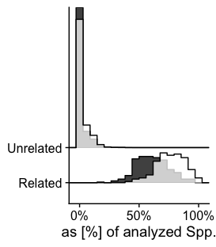

```r
plot.control <-
  sstr %>%
  filter(Study.row %in% control.studies &
         Study.col %in% control.studies) %>%
  mutate(Related.text = ifelse(Related.bool, 'Related', 'Unrelated')) %>%
  pivot_longer(names_to = 'metric', values_to = 'value',
               cols = c('f.shared_strains.mvs', 'f.shared_strains.cvs')) %>%
mutate(metric = case_when(
  metric == 'f.shared_strains.mvs' ~ 'SameStr',
  metric == 'f.shared_strains.cvs' ~ 'Consensus',
)) %>%
ggplot(aes(value, Related.text, fill = metric)) +
  geom_density_ridges(alpha = 0.75, scale = 4, stat = 'binline', bins = 18) +  # scale = 4
  scale_x_continuous(labels = percent_format(), expand = c(0,0), breaks = c(0, 0.5, 1)) +
  scale_fill_manual(values = c('black','white')) +
  theme_cowplot() +
  labs(x = 'as [%] of analyzed Spp.') +
  theme(legend.title = element_blank(),
        axis.title.y = element_blank(),
        )
plot.control + theme(legend.position = 'none')
```

Exporting Plot

```r
output_name = 'SharedStrains.Control'

ggsave(plot.control + theme(legend.position = 'none'),
       device = 'pdf', dpi = 300, width = 2.85, height = 3.25,
       filename = paste0(results_dir, fig, output_name, '.RidgePlot.pdf'))
```

```r
sstr.control %>%
  select(Related.text, n.shared_strains.mvs) %>%
  group_by(Related.text) %>%
  summarize_all(.funs = funs(n(), min, max, median, mean, sd))
```

| Related.text | n | min | max | median | mean | sd |
| --- | --- | --- | --- | --- | --- | --- |
| Related | 281 | 4 | 43 | 14 | 16.1245552 | 6.7777579 |
| Unrelated | 20020 | 0 | 4 | 0 | 0.2776224 | 0.5487829 |

# Tool Comparison

## Format

Merge Tool Data

```r
alm_table <-
  sf %>%
  left_join(., sstr.alm %>%
  rename_at(.vars = vars(n.shared_strains.mvs,
                         n.shared_species,
                         n.shared_genus,
                         n.shared_family,
                         f.shared_strains.mvs,
                         f.shared_species,
                         f.shared_genus,
                         f.shared_family),
            .funs = funs(paste0(gsub(., pattern = '.mvs', replacement = ''), '.sstr'))) %>%

  rowwise() %>%
  mutate(Name.paste = paste0(sort(c(Name.row, Name.col)), collapse = ',')) %>%
  ungroup() %>%
  select(-Name.row, -Name.col, -Case_Name.row, -Case_Name.col)) %>%

  # label study, case
  mutate(Case_Split.row = str_split(Case_Name.row, ';'),
         Case_Split.col = str_split(Case_Name.col, ';')) %>%
  rowwise() %>%
  mutate(Study.same = Study.row == Study.col,
         Study.pair = ifelse(Study.same, Study.row, 'Unrelated'),
         Case_Name.same = (Case_Name.col %in% Case_Split.row) | (Case_Name.row %in% Case_Split.col),
         Case_Name.pair = ifelse(Case_Name.same, intersect(Case_Split.row, Case_Split.col), 'Unrelated')) %>%
  select(-starts_with('Case_Split.')) %>%
  ungroup() %>%

  # label comparison type + study, case
  mutate(
    Pair_Type = 'No-Pair',
    Pair_Type = case_when(


    (Sample_Type.row == 'recipient' & Sample_Type.col == 'donor') |
    (Sample_Type.col == 'recipient' & Sample_Type.row == 'donor') ~ 'Pre-FMT/Donor',

    (Sample_Type.row == 'post' & Sample_Type.col == 'recipient') |
    (Sample_Type.col == 'post' & Sample_Type.row == 'recipient') ~ 'Pre-FMT/Post-FMT',

    (Sample_Type.row == 'post' & Sample_Type.col == 'donor') |
    (Sample_Type.col == 'post' & Sample_Type.row == 'donor') ~ 'Donor/Post-FMT',

    Sample_Type.row == 'recipient' & Sample_Type.col == 'recipient' ~ 'Pre-FMT/Pre-FMT',
    Sample_Type.row == 'post' & Sample_Type.col == 'post' ~ 'Post-FMT/Post-FMT',
    Sample_Type.row == 'donor' & Sample_Type.col == 'donor' ~ 'Donor/Donor')) %>%

  # label family relationship
  mutate(Same_Case.label = ifelse(Case_Name.same, 'Same Case', 'Distinct Case'),
         Same_Study.label = ifelse(Study.same, 'Same Study', 'Distinct Study'),
         ) %>%

  select(Name.paste, contains('n.shared'), starts_with('f.'), ends_with('.pair'),
         Related.label, Related.bool, Pair_Type) %>%
  mutate(Related.text = ifelse(Related.bool, 'Related', 'Unrelated'))
```

```r
alm_table.n <-
  alm_table %>%
  pivot_longer(names_to = 'metric', values_to = 'value',
               cols = starts_with('n.shared')) %>%
  separate(metric, into = c('metric','taxonomic_level','tool'), sep = '[.]') %>%
  mutate(taxonomic_level = gsub(taxonomic_level, pattern = 'shared_', replacement = ''),
         taxonomic_level = gsub(taxonomic_level, pattern = 'strains', replacement = 'strain')) %>%
  select(-metric)

alm_table.f <-
  alm_table %>%
  pivot_longer(names_to = 'metric', values_to = 'value',
               cols = starts_with('f.shared')) %>%
  separate(metric, into = c('metric','taxonomic_level','tool'), sep = '[.]') %>%
  mutate(taxonomic_level = gsub(taxonomic_level, pattern = 'shared_', replacement = ''),
         taxonomic_level = gsub(taxonomic_level, pattern = 'strains', replacement = 'strain')) %>%
  select(-metric)
```

## Shared Strains n

Number of shared strains between related and unrelated samples of the ALM rCDI cohort based on CVS, MVS of MetaPhlAn2 alignments and Strain Finder on AMPHORA markers

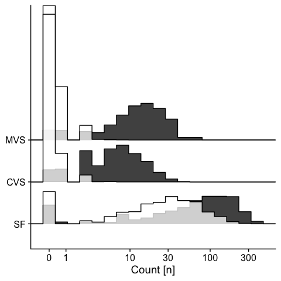

```r
plot.strain_count <-

  alm_table.n %>%
  filter(taxonomic_level == 'strain') %>%

  mutate(tool = case_when(
    tool == 'sstr' ~ 'MVS',
    tool == 'sf' ~ 'SF',
    tool == 'cvs' ~ 'CVS',
    T ~ tool)) %>%

  mutate(tool = fct_relevel(tool,'SF','CVS','MVS')) %>%

  ggplot(aes(value, tool, fill = Related.text)) +
  geom_density_ridges(alpha = 0.75, scale = 4, stat = 'binline', bins = 18) +
  scale_x_continuous(expand = c(0,0),
                     trans = pseudo_log_trans(1, base = 10),
                     breaks = c(0, 1, 10, 30, 100, 300)
) +
  theme_cowplot() +
  labs(x = 'Count [n]') +
  scale_fill_manual(values = c('black', 'white')) +
  theme(strip.background = element_blank(),
        axis.title.y = element_blank(),
        legend.title = element_blank(),
        legend.position = c(0.6, 0.9))


legend <- cowplot::get_legend(plot.strain_count)
plot.strain_count + theme(legend.position = 'none')
```

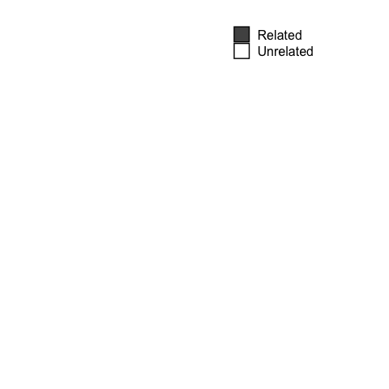

```r
grid.newpage()
grid.draw(legend)
```

Whereas Strain Finder is finding a lot of co-occurring strains in unrelated samples, the consensus approach is very conservative. Compared to SameStr MVS, consensus finds slightly fewer potential false-positives (means ~.45 vs. .22 strains in unrelated samples) but also misses on a large fraction of potential true-positives (means ~15 vs. 8 in related samples)

```r
alm_table.n %>%
  filter(taxonomic_level == 'strain') %>%
  ungroup() %>%
  mutate(tool = case_when(
    tool == 'sstr' ~ 'MVS',
    tool == 'sf' ~ 'SF',
    tool == 'cvs' ~ 'CVS',
    T ~ tool)) %>%
  select(Name.paste, Related.text, tool, value) %>%
  pivot_wider(names_from = 'tool', values_from = 'value') %>%
  mutate(`SF-MVS` = SF - MVS) %>%
  select(-Name.paste) %>%
  group_by(Related.text) %>%
  summarize_all(.funs = funs(n(), min, max, median, mean, sd)) %>%
  group_by(Related.text) %>%
  mutate_all(.funs = funs(round(., 2))) %>%
  pivot_longer(names_to = 'names', values_to = 'value', cols = matches('.*_.*')) %>%
  separate(names, into = c('tool','metric'), sep = '_') %>%
  pivot_wider(names_from = 'metric', values_from = 'value')
```

```
`mutate_all()` ignored the following grouping variables:
Column `Related.text`
Use `mutate_at(df, vars(-group_cols()), myoperation)` to silence the message.
```

| Related.text | tool | n | min | max | median | mean | sd |
| --- | --- | --- | --- | --- | --- | --- | --- |
| Related | SF | 555 | 0 | 384 | 73 | 93.13 | 82.59 |
| Related | MVS | 555 | 0 | 67 | 12 | 14.77 | 11.34 |
| Related | CVS | 555 | 0 | 44 | 6 | 7.99 | 6.83 |
| Related | SF-MVS | 555 | -9 | 335 | 59 | 78.35 | 73.50 |
| Unrelated | SF | 1525 | 0 | 238 | 25 | 35.16 | 37.68 |
| Unrelated | MVS | 1525 | 0 | 8 | 0 | 0.45 | 0.75 |
| Unrelated | CVS | 1525 | 0 | 6 | 0 | 0.22 | 0.55 |
| Unrelated | SF-MVS | 1525 | -3 | 237 | 25 | 34.71 | 37.52 |

## Shared Strains %

Fraction of shared strains betweent related and unrelated samples of the ALM rCDI cohort

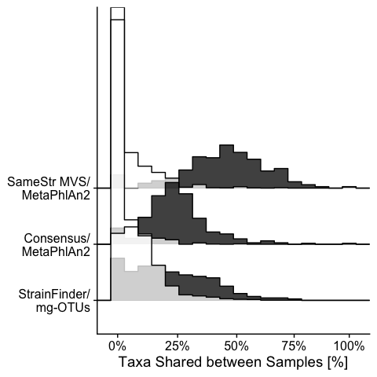

```r
plot.strain_fraction <-

  alm_table.f %>%
  filter(taxonomic_level == 'strain') %>%

  mutate(tool = case_when(
    tool == 'sstr' ~ 'SameStr MVS/\nMetaPhlAn2',
    tool == 'sf' ~ 'StrainFinder/\nmg-OTUs',
    tool == 'cvs' ~ 'Consensus/\nMetaPhlAn2',
    T ~ tool)) %>%

  mutate(tool = fct_relevel(tool,
    'StrainFinder/\nmg-OTUs',
    'Consensus/\nMetaPhlAn2',
    'SameStr MVS/\nMetaPhlAn2',
  )) %>%

  ggplot(aes(value, tool, fill = Related.text)) +
  geom_density_ridges(alpha = 0.75, scale = 4, stat = 'binline', bins = 18) +
  scale_x_continuous(expand = c(0,0),
                     trans = pseudo_log_trans(base = 10),
                     labels = percent_format()
) +
  theme_cowplot() +
  labs(x = 'Taxa Shared between Samples [%]') +
  scale_fill_manual(values = c('black', 'white')) +
  theme(strip.background = element_blank(),
        axis.title.y = element_blank(),
        legend.title = element_blank(),
        legend.position = c(0.6, 0.9))

plot.strain_fraction + theme(legend.position = 'none')
```

Exporting Plot

```r
output_name = 'SharedStrains.Alm'

ggsave(plot.strain_count + theme(legend.position = 'none'),
       device = 'pdf', dpi = 300, width = 3.5, height = 3.25,
       filename = paste0(results_dir, fig, output_name, '.Counts', '.RidgePlot.pdf'))
ggsave(plot.strain_fraction + theme(legend.position = 'none', axis.line.y = element_blank()),
       device = 'pdf', dpi = 300, width = 5, height = 4,
       filename = paste0(results_dir, fig, output_name, '.Fraction', '.RidgePlot.pdf'))
ggsave(legend,
       device = 'pdf', dpi = 300, width = 5, height = 5,
       filename = paste0(results_dir, fig, output_name, '.Legend.pdf'))
```

## Shared F>G>Spp. %

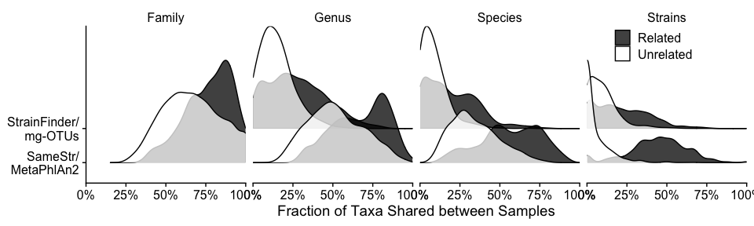

```r
alm_table %>%
  pivot_longer(names_to = 'metric', values_to = 'value',
               cols = starts_with('f.shared')) %>%
  separate(metric, into = c('metric','taxonomic_level','tool'), sep = '[.]') %>%
  select(-metric) %>%
  filter(tool != 'cvs') %>%
  mutate(taxonomic_level = str_to_title(gsub(taxonomic_level, pattern = 'shared_', replacement = ''))) %>%
  mutate(tool = case_when(tool == 'sstr' ~ 'SameStr/\nMetaPhlAn2', tool == 'sf' ~ 'StrainFinder/\nmg-OTUs', T ~ tool)) %>%

  ggplot(aes(value, tool, fill = Related.text)) +
  geom_density_ridges(alpha = 0.75, scale = 3) +
  scale_x_continuous(limits = c(0, 1), labels = percent_format(), expand = c(0,0)) +
  theme_cowplot() +
  labs(x = 'Fraction of Taxa Shared between Samples') +
  scale_fill_manual(values = c('black', 'white')) +
  facet_wrap(~taxonomic_level, nrow = 1, scales = 'free_x') +
  theme(strip.background = element_blank(),
        axis.title.y = element_blank(),
        legend.title = element_blank(),
        legend.position = c(0.8, 0.9))
```

# Sensitivity of Taxa Detection

## Format

Comparison of genera found with MP2/Amphora

```r
counts <-
  full_join(sf_genus_counts, sf_species_counts, by = 'Sample') %>%
  mutate(Name = paste0('ALM_', Sample, '.pair')) %>%
  full_join(., taxa_counts %>%
              rename(Name = 'Sample') %>% select(-n.family),
            by = 'Name', suffix = c('.sf','.mp')) %>%
  filter(!is.na(n.species.mp), !is.na(n.species.sf))
```

```r
lm_eqn <- function(df){
    m <- lm(mp ~ sf, df);
    eq <- substitute(italic(y) == a + b %.% italic(x)*","~~italic(r)~"="~rv,
         list(a = format(unname(coef(m)[1]), digits = 2),
              b = format(unname(coef(m)[2]), digits = 2),
             rv = format(sqrt(summary(m)$r.squared), digits = 2)))
    as.character(as.expression(eq));
}
counts.data <- counts %>%
  pivot_longer(names_to = 'metric', values_to = 'n', cols = starts_with('n.')) %>%
  separate(metric, into = c('metric','taxonomic_level','tool'), sep = '[.]') %>%
  select(-metric) %>%
  pivot_wider(names_from = 'tool', values_from = 'n') %>%
  mutate(difference = mp - sf)

counts.data.genus <-
  counts.data %>%
  filter(taxonomic_level == 'genus')

counts.data.species <-
  counts.data %>%
  filter(taxonomic_level == 'species')
```

```r
get_stats <- function(df, digits = 2) {
  df.mean <- mean(df, na.rm = T)
  df.sd <- sd(df, na.rm = T)
  df.format <- paste('µ=', round(df.mean, digits = digits),  '±', round(df.sd, digits = digits), sep = '')
  return(
    list(
      'mean' = df.mean,
      'sd' = df.sd,
      'format' = df.format))
}
digits = 1
stats.g.diff <- get_stats(counts.data.genus$difference, digits = digits)
stats.g.mp <- get_stats(counts.data.genus$mp, digits = digits)
stats.g.sf <- get_stats(counts.data.genus$sf, digits = digits)
stats.s.diff <- get_stats(counts.data.species$difference, digits = digits)
stats.s.mp <- get_stats(counts.data.species$mp, digits = digits)
stats.s.sf <- get_stats(counts.data.species$sf, digits = digits)
```

## Statistics

```r
counts.data %>%
  select(-Sample, -Name) %>%
  group_by(taxonomic_level) %>%
  summarize_all(.funs = funs(mean, sd)) %>%
  select(taxonomic_level, starts_with('sf_'), starts_with('mp_'), starts_with('dif')) %>%
  mutate_at(.vars = vars(everything(), -taxonomic_level),
            .funs = funs(round(., digits = 2)))
```

| taxonomic_level | sf_mean | sf_sd | mp_mean | mp_sd | difference_mean | difference_sd |
| --- | --- | --- | --- | --- | --- | --- |
| genus | 23.78 | 16.67 | 50.54 | 15.0 | 26.75 | 8.98 |
| species | 48.48 | 33.88 | 97.62 | 39.6 | 49.14 | 19.88 |

genus: sf = 23.78 +- 16.67 mp = 50.54 +- 15.0

species: sf = 48.48 +- 33.88 mp = 97.62 +- 39.6 ## Detected Taxa per Sample

```r
yy.s = 80
yy.g = 30
nudge = 70

plot <-
  counts.data %>%
  ggplot(aes(y = mp, x = sf, fill = taxonomic_level)) +
  geom_point(shape = 21, col = 'black', size = 5) +

  annotate(geom = 'text', y = yy.s, x = yy.s + nudge + 5, label = stats.s.diff$format, size = 5, parse = F) +
  annotate(geom = 'text', y = yy.g, x = yy.g + nudge, label = stats.g.diff$format, size = 5, parse = F) +

  annotate("segment", show.legend = F,
           arrow = arrow(length = unit(0.3, "cm"), type = "closed"), size = 1, col = 'black',
   y=yy.s, yend=yy.s + stats.s.diff$mean, x=yy.s, xend=yy.s) +
  annotate("segment", show.legend = F,
           arrow = arrow(length = unit(0.3, "cm"), type = "closed"), size = 1, col = 'black',
   y=yy.g, yend=yy.g + stats.g.diff$mean, x=yy.g, xend=yy.g) +

  geom_abline(slope = 1, intercept = 0, linetype = 'dashed') +

  theme_cowplot() +
  scale_x_continuous(limits = c(0, 200)) +
  scale_y_continuous(limits = c(0, 200)) +
  scale_fill_manual(values = c('grey25', 'white')) +
  scale_color_manual(values = c('black', 'black')) +
  theme(aspect.ratio = 1,
        plot.subtitle = element_text(hjust = 0.5),
        legend.title = element_blank(),
        legend.position = c(0.02, 0.9)) +
  labs(y = 'SameStr / MetaPhlAn2', x = 'Strain Finder / mg-OTUs', subtitle = 'Detected Taxa per Sample')
```

```
Ignoring unknown parameters: show.legendIgnoring unknown parameters: show.legend
```

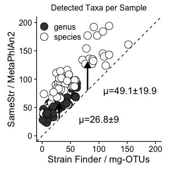

```r
plot
```

Exporting Plot

```r
output_name = 'DetectedTaxa.Species.Alm'

ggsave(plot,
       device = 'pdf', dpi = 300, width = 3.75, height = 3.75,
       filename = paste0(results_dir, fig, output_name, '.CorrPlot.pdf'))
```

## Taxa Differences

Number of detected mg-OTUs: species == 306 genus == 116

```r
sf_strain_table %>%
  mutate_at(.vars = vars(everything(), -Sample),
            .funs = funs(as.numeric(. > 0))) %>%
  pivot_longer(names_to = 'tax', values_to = 'rel_abund', cols = starts_with('BACT')) %>%
  separate(col = tax, into = c('bact', 'gdna'), sep = ';') %>%
  select(-gdna) %>%
  group_by(bact) %>%
  summarize(present = as.numeric(sum(rel_abund, na.rm = T) > 0)) %>%
  summarize(count = sum(present, na.rm = T))
```

| count |
| --- |
| 306 |

```r
sf_strain_table %>%
  mutate_at(.vars = vars(everything(), -Sample),
            .funs = funs(as.numeric(. > 0))) %>%
  pivot_longer(names_to = 'tax', values_to = 'rel_abund', cols = starts_with('BACT')) %>%
  separate(col = tax, into = c('bact', 'gdna'), sep = ';') %>%
  select(-gdna) %>%
  group_by(Sample, bact) %>%
  summarize(rel_abund = as.numeric(sum(rel_abund, na.rm = T) > 0)) %>%
  left_join(., sf_species_table %>% select(bact, genus), by = 'bact') %>%
  group_by(genus) %>%
  summarize(present = as.numeric(sum(rel_abund, na.rm = T) > 0)) %>%
  summarize(count = sum(present, na.rm = T))
```

| count |
| --- |
| 116 |

Number of detected MetaPhlAn2 species: species == 399 genus == 154

```r
mp_species.long %>%
  select(species, Name, rel_abund) %>%
  filter(grepl(Name, pattern = '^ALM'), rel_abund > 0) %>%
  filter(!grepl(species, pattern = 'unclassified')) %>%
  group_by(species) %>%
  summarize(present = sum(rel_abund > 0, na.rm = T)) %>%
  summarize(count = sum(present > 0, na.rm = T))
```

| count |
| --- |
| 399 |

```r
mp_species.long %>%
  select(genus, Name, rel_abund) %>%
  filter(grepl(Name, pattern = '^ALM'), rel_abund > 0) %>%
  filter(!grepl(genus, pattern = 'unclassified')) %>%
  group_by(genus) %>%
  summarize(present = sum(rel_abund > 0, na.rm = T)) %>%
  summarize(count = sum(present > 0, na.rm = T))
```

| count |
| --- |
| 154 |

### Format

```r
found_sf <-
  sf_strain_table %>%
  mutate_at(.vars = vars(everything(), -Sample),
            .funs = funs(as.numeric(. > 0))) %>%
  pivot_longer(names_to = 'tax', values_to = 'rel_abund', cols = starts_with('BACT')) %>%
  separate(col = tax, into = c('bact', 'gdna'), sep = ';') %>%
  select(-gdna) %>%
  group_by(Sample, bact) %>%
  summarize(rel_abund = as.numeric(sum(rel_abund, na.rm = T) > 0), .groups = 'drop') %>%
  left_join(., sf_species_table %>% select(bact, genome, genus), by = 'bact') %>%
  group_by(Sample, genus) %>%
  summarize(species_count.sf = sum(rel_abund, na.rm = T), .groups = 'drop')
found_mp <-
  mp_species.long %>%
  select(genus, species, Name, rel_abund) %>%
  filter(grepl(Name, pattern = '^ALM'), rel_abund > 0) %>%
  mutate(genus = gsub(genus, pattern = '_noname', replacement = '')) %>%
  group_by(genus, Name) %>%
  summarize(species_count.mp = sum(rel_abund > 0, na.rm =T), .groups = 'drop') %>%
  mutate(Sample = gsub(str_split_fixed(Name, pattern = '_', 2)[,2], pattern = '.pair', replacement = '')) %>%
  select(-Name)

taxa.genus.important <-
  full_join(found_sf, found_mp) %>%
  mutate_at(.vars = vars(starts_with('species_count')),
            .funs = funs(ifelse(is.na(.), 0, .))) %>%
  group_by(genus) %>%
  summarize(species_count.sf = sum(species_count.sf, na.rm = T),
            species_count.mp = sum(species_count.mp, na.rm = T), .groups = 'drop') %>%
  mutate(total = species_count.mp + species_count.sf) %>%
  arrange(desc(total)) %>%
  top_n(30, total) %>%
  pull(genus)
found <-
  full_join(found_sf, found_mp) %>%
  mutate_at(.vars = vars(starts_with('species_count')),
            .funs = funs(ifelse(is.na(.), 0, .))) %>%
  filter(genus %in% taxa.genus.important)
```

### Ridge Plot

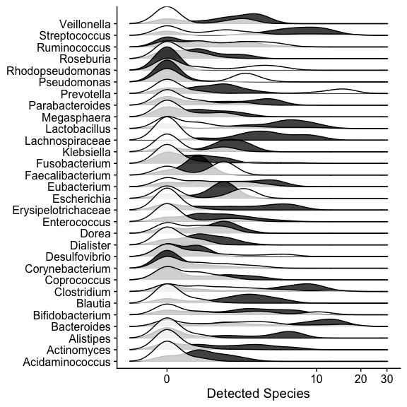

```r
plot <-
  found %>%
  pivot_longer(names_to = 'metric', values_to = 'count', cols = c('species_count.sf', 'species_count.mp')) %>%
  mutate(metric = case_when(
    metric == 'species_count.sf' ~ 'mg-OTUs',
    metric == 'species_count.mp' ~ 'MetaPhlAn2',
  )) %>%

  ggplot(aes(count, genus, fill = metric)) +
  geom_density_ridges(panel_scaling = F, alpha = 0.75, scale = 2) +
  scale_x_continuous(trans = pseudo_log_trans()) +
  labs(x = 'Detected Species') +
  theme_cowplot() +
  theme(axis.title.y = element_blank()) +
  scale_fill_manual(values = c('black','white'))

plot + theme(legend.position = 'none')
```

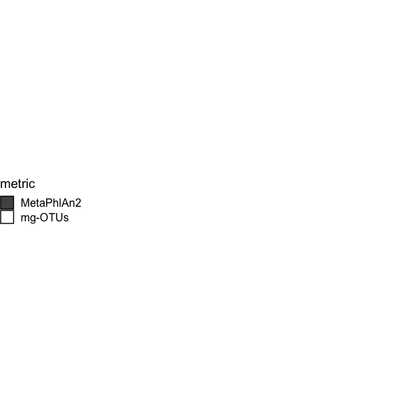

```r
legend <- cowplot::get_legend(plot)
grid.newpage()
grid.draw(legend)
```

Exporting Plot

```r
output_name = 'DetectedTaxa.Species.Alm'

ggsave(plot + theme(legend.position = 'none'),
       device = 'pdf', dpi = 300, width = 4, height = 6,
       filename = paste0(results_dir, fig, output_name, '.RidgePlot.pdf'))
ggsave(legend,
       device = 'pdf', dpi = 300, width = 1.25, height = 1.5,
       filename = paste0(results_dir, fig, output_name, '.Legend.pdf'))
```

```r
found %>%
  ungroup() %>%
  select(-Sample) %>%
  group_by(genus) %>%
  summarize_all(.funs = funs(mean, sd)) %>%
  mutate(diff = species_count.sf_mean - species_count.mp_mean) %>%
  group_by(genus) %>%
  mutate_all(.funs = funs(round(., 2))) %>%
  ungroup() %>%
  rename_at(.vars = vars(starts_with('species_')),
            .funs = funs(gsub(., pattern = 'species_count.', replacement = ''))) %>%
  select(genus, starts_with('sf'), starts_with('mp'), diff) %>%
  arrange(diff) %>%
  head(10)
```

```
`mutate_all()` ignored the following grouping variables:
Column `genus`
Use `mutate_at(df, vars(-group_cols()), myoperation)` to silence the message.
```

| genus | sf_mean | sf_sd | mp_mean | mp_sd | diff |
| --- | --- | --- | --- | --- | --- |
| Lachnospiraceae | 0.00 | 0.00 | 4.98 | 2.65 | -4.98 |
| Streptococcus | 2.68 | 4.02 | 6.70 | 4.13 | -4.01 |
| Lactobacillus | 1.41 | 2.37 | 5.06 | 3.33 | -3.66 |
| Erysipelotrichaceae | 0.06 | 0.25 | 2.90 | 2.58 | -2.84 |
| Bacteroides | 3.87 | 4.70 | 6.54 | 5.35 | -2.67 |
| Blautia | 0.19 | 0.43 | 2.75 | 1.84 | -2.56 |
| Alistipes | 0.14 | 0.35 | 2.59 | 2.87 | -2.46 |
| Clostridium | 2.43 | 3.25 | 4.81 | 4.05 | -2.38 |
| Actinomyces | 0.18 | 0.50 | 2.20 | 2.17 | -2.03 |
| Veillonella | 0.73 | 1.25 | 2.32 | 1.50 | -1.58 |

## Genus SF vs. MP

# SF Majority Strain

```r
sf_min_abund <- function(min_abund) {

  sf_strain_table.matrix <-
  sf_strain_table %>%
  mutate_at(.vars = vars(everything(), -Sample),
            .funs = funs(as.numeric(. > min_abund))) %>% # set > .5 filter here to compare SF majority strains
  column_to_rownames('Sample') %>%
  as.matrix()

colnames(sf_strain_table.matrix) <-
  tibble(tax = colnames(sf_strain_table.matrix)) %>%
  separate(col = tax, into = c('bact', 'gdna'), sep = ';') %>%
  group_by(bact) %>%
  mutate(strain_id = paste0(bact, '.', dense_rank(gdna))) %>%
  pull(strain_id)

# strain
sf_strain_table.dist <- sf_strain_table.matrix %*% t(sf_strain_table.matrix)
sf_strain_table.long <-
  distmat_to_long(distmat = as.data.frame(sf_strain_table.dist),
                  value_name = paste0('n.shared_strains.', 'min_abund_', min_abund),
                  rm_diag = T)
return(sf_strain_table.long)
}

df <- sf_min_abund(0)
for (m in c(5e-3, 5e-2, 5e-1)) {
  df <- full_join(df, sf_min_abund(m), by = c('row','col'))
}


related.v <-
  alm_table.n %>%
  filter(taxonomic_level == 'strain', tool == 'sf') %>%
  select(Name.paste, Related.text)

sf <-
  df %>%

  rename(Sample.row = row,
         Sample.col = col,
         ) %>%

  rename_at(.vars = vars(matches('n.*col'), matches('n.*row')),
            .funs = funs(gsub(gsub(., pattern = '.row', replacement = '.sf.row'),
                              pattern = '.col', replacement = '.sf.col'))) %>%
  left_join(., samples.metadata, by = c('Sample.row' = 'Sample')) %>%
  left_join(., samples.metadata, by = c('Sample.col' = 'Sample'), suffix = c('.row', '.col')) %>%
  filter(!is.na(Name.row), !is.na(Name.col)) %>%
  rowwise() %>%
  mutate(Name.paste = paste0(sort(c(Name.row, Name.col)), collapse = ',')) %>%
  ungroup() %>%
  left_join(., related.v) %>%
  # mutate(related = ifelse(replace_na(Donor.Subject.row == Donor.Subject.col, F), 'Related', 'Unrelated')) %>%
  pivot_longer(names_to = 'metric', values_to = 'value',
               cols = starts_with('n.shared_strains')) %>%
  separate(metric, into = c('metric','min_abund'), sep = '.abund_') %>%
  mutate(min_abund = as.numeric(min_abund))
```

Strain Finder shows a high number of cooccurring strains in unrelated sample pairs. Cooccurrence distributions of related / unrelated sample pairs overlap widely, even when considering only strains that were detected at >=50% strain abundance in the species population - a problem that might be due to the amphora markers.

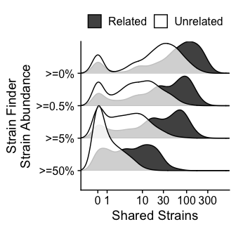

```r
plot <-
  sf %>%

  mutate(metric = paste0('>=', round(min_abund * 100, 5), '%')) %>%

  ggplot(aes(value, fct_reorder(metric, min_abund, .desc = T), fill = Related.text)) +
  geom_density_ridges(alpha = 0.75, scale = 2) +
  scale_fill_manual(values = c('black','white')) +
  scale_x_continuous(expand = c(0,0),
                     trans = pseudo_log_trans(1, base = 10),
                     breaks = c(0, 1, 10, 30, 100, 300)
) +
  theme_cowplot() +
  theme(aspect.ratio = 1) +
  labs(x = 'Shared Strains', y = 'Strain Finder\nStrain Abundance') +
  theme(legend.title = element_blank(),
        legend.position = 'top')
plot
```

Exporting plot

```r
output_name = 'StrainFinder.StrainCooccurrence'

ggsave(plot,
       device = 'pdf', dpi = 300, width = 4, height = 4,
       filename = paste0(results_dir, fig, output_name, '.Plot.pdf'))
```

# Mock Multi-Strain Species Population

Detecting strains hidden in Mock Multi-Strain Species Population with varying numbers of strains, target coverage, noise coverage and total coverage.

## Format

```r
percent_format_signif <-
  function(x, label.precision=3, label.percent=T) {
    if (label.percent == T) {
      paste0(signif(100 * x, label.precision), "%")
    } else {
      signif(digits = label.precision)
    }
  }
```

Calculate metrics

```r
df <-
  mock.sstr_data %>%

  pivot_longer(names_to = 'metric',
               values_to = 'distance',
               cols = c('distance.mvs', 'distance.cvs')) %>%
  mutate(shared = distance > min_similarity & overlap > min_overlap,
         should = tsc > 0,
         TP = shared & should,
         FP = shared & !should,
         TN = !shared & !should,
         FN = !shared & should,
         event = case_when(
           TP ~ 'TP',
           FP ~ 'FP',
           TN ~ 'TN',
           FN ~ 'FN',
           T ~ 'Unknown'
         )) %>%
  mutate(metric = case_when(
    metric == 'distance.cvs' ~ 'Consensus (CVS)',
    metric == 'distance.mvs' ~ 'SameStr (MVS)',
    T ~ 'Unknown'
  )) %>%
  group_by(metric, tsc, ngc, total_coverage, rel_abund.target) %>%
  summarize(TP = sum(TP, na.rm = T),
            FP = sum(FP, na.rm = T),
            TN = sum(TN, na.rm = T),
            FN = sum(FN, na.rm = T),
            .groups = 'drop') %>%
  mutate(Precision = TP / (TP + FP),
    Recall = TP / (TP + FN),
    `Precision/Recall` = Precision / Recall,
    Accuracy = (TP+TN)/(TP+FP+FN+TN),
    `Error Rate` = 1 - Accuracy)
```

N Mock Observations

```r
nrow(mock.sstr_data)
```

```
[1] 3276
```

## Accuracy Heatmap

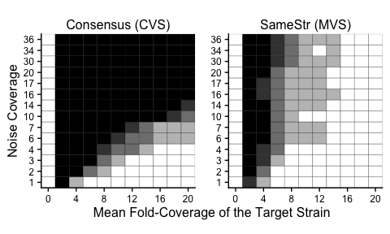

```r
plot <-
  df %>%
  mutate(`Error Rate` =
         Hmisc::cut2(`Error Rate`,
                   cuts = seq(0, 1, 0.2),
                   minmax = T,
                   formatfun = scales::percent,
                   oneval = F) %>%
         as.character() %>%
         gsub(pattern = '\\[', replacement = '') %>%
         gsub(pattern = '\\]', replacement = '') %>%
         gsub(pattern = '\\)', replacement = '') %>%
         gsub(pattern = ',', replacement = '-')) %>%
  filter(ngc > 0) %>%
  ggplot(aes(
    tsc,
    as.factor(ngc))
    ) +
  geom_tile(aes(fill = `Error Rate`), col = 'black') +
  scale_x_continuous(expand = c(0,0),
                     breaks = seq(0, 20, 4)) +
  scale_y_discrete(expand = c(0,0)) +
  facet_wrap(~ metric, scales = 'free_y') +
  theme_cowplot() +
  theme(aspect.ratio = 1,
        strip.background = element_blank(),
        panel.spacing.x = unit(1, "lines"),
        axis.text = element_text(size = 9),
        axis.title = element_text(size = 12),
        axis.title.x = element_text(hjust = 0.5),
        legend.position = 'right',
        legend.title = element_text(size = 12),
        legend.key = element_rect(colour = "black")) +
  labs(x = 'Mean Fold-Coverage of the Target Strain',
       y = 'Noise Coverage') +
  scale_fill_manual(values = c('white', 'gray75', 'gray50', 'gray25', 'black'))
plot + theme(legend.position = 'none')
```

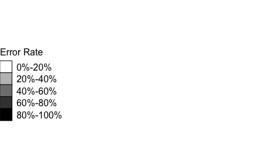

```r
legend <- cowplot::get_legend(plot)
grid.newpage()
grid.draw(legend)
```

Exporting Plot

```r
output_name = 'AccuracyHeatmap.Mock'

ggsave(plot + theme(legend.position = 'none'),
       device = 'pdf', dpi = 300, width = 5.5, height = 3,
       filename = paste0(results_dir, fig, output_name, '.Plot.pdf'))
ggsave(legend,
       device = 'pdf', dpi = 300, width = 1.25, height = 1.5,
       filename = paste0(results_dir, fig, output_name, '.Legend.pdf'))
```

Comparison of average detection accuracy using Consensus vs. SameStr MVS with at least 5x coverage when target strain is dominant (>50% species population) or sub-dominant (15-50% species population)

```r
df %>%
  mutate(miss_rate = TP / (FN + TP)) %>%
  filter(rel_abund.target > .5, total_coverage > 5) %>%
  group_by(metric) %>%
  summarize(Accuracy = 1 - mean(`Error Rate`, na.rm = T))
```

| metric | Accuracy |
| --- | --- |
| Consensus (CVS) | 0.5882353 |
| SameStr (MVS) | 0.8522059 |

```r
df %>%
  filter(rel_abund.target > .15) %>%
  filter(rel_abund.target <= .5, total_coverage > 5) %>%
  group_by(metric) %>%
  summarize(Accuracy = 1 - mean(`Error Rate`, na.rm = T))
```

| metric | Accuracy |
| --- | --- |
| Consensus (CVS) | 0.0171875 |
| SameStr (MVS) | 0.5796875 |

# Phylogenetic Resolution of MP Markers

Comparing full-genome based Fast-ANI scores to MetaPhlAn2 based similarity

## Reference Genomes

Similarity Distribution of Reference Genomes

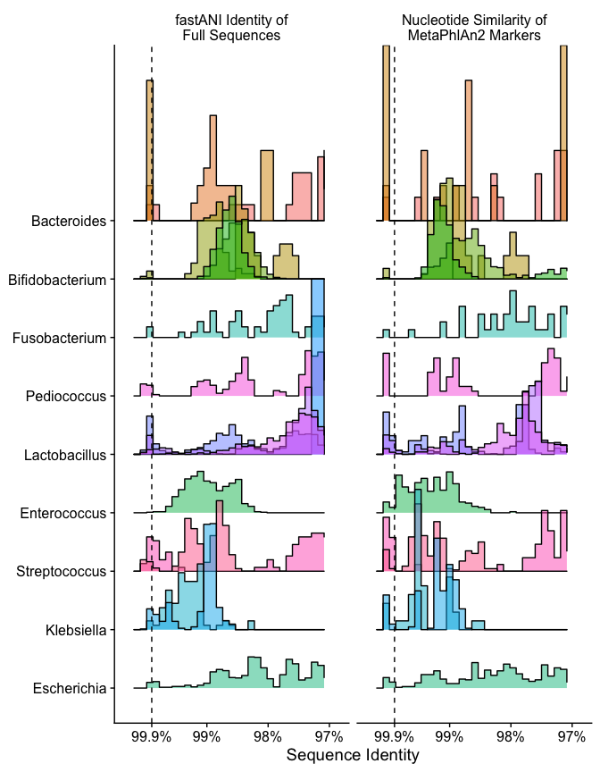

```r
percent_format_signif <- function(x, label.precision=3, label.percent=T) {
    if (label.percent == T) {
      paste0(signif(100 * x, label.precision), "%")
    } else {
      signif(digits = label.precision)
    }
}

species_ridge <-
  refs %>%
  filter(distance > .97 | ani > .97) %>%
  pivot_longer(values_to = 'value', names_to = 'metric', cols = c('distance', 'ani')) %>%
  mutate(metric = case_when(
    metric == 'distance' ~ 'Nucleotide Similarity of\nMetaPhlAn2 Markers',
    metric == 'ani' ~ 'fastANI Identity of\nFull Sequences',
    T ~ metric
  )) %>%
  ggplot(aes(x = value,
             y = fct_reorder(genus, genus_avg_marker_len),
             group = species,
             fill = species)) +
  geom_density_ridges(scale = 3,
                     alpha = 0.5, stat = 'binline', show.legend = F,
                     ) +
  scale_x_reverse(labels = percent_format_signif,
                  breaks=c(min_similarity, 0.99, 0.98, 0.97),
                  limits = c(NA, 0.97),
                  expand = c(0.1, 0)) +
  theme_cowplot() +
  geom_vline(xintercept = min_similarity, show.legend = T, linetype = 'dashed') +
  guides(fill = guide_legend(ncol = 1)) +
  labs(x = 'Sequence Identity') +
  facet_grid(cols = vars(metric)) +
  theme(strip.background = element_blank(),
        axis.title.y = element_blank())

species_ridge
```

```r
refs %>%
  pivot_longer(values_to = 'value', names_to = 'metric', cols = c('distance', 'ani')) %>%
  group_by(metric) %>%
  summarize(not_shared = sum(value < min_similarity, na.rm = T),
            shared = sum(value > min_similarity, na.rm = T)) %>%
  mutate(total = not_shared + shared,
         rate = shared / total * 100)
```

| metric | not_shared | shared | total | rate |
| --- | --- | --- | --- | --- |
| ani | 14604 | 316 | 14920 | 2.117962 |
| distance | 14366 | 554 | 14920 | 3.713137 |

Correlation of MP marker vs. fastANI based similarity

```r
min = .97
refs.cor <-
  cor.test(~ ani + distance,
           data = refs %>%
             filter(!is.na(ani), !is.na(distance)) %>%
             filter(ani > min & distance > min),
           method = 'spearman') %>%
  broom::tidy(.) %>%
  mutate(estimate.round = round(estimate, 2),
         sig = cut(p.value,
                   breaks = c(-Inf, 0.001, 0.01, 0.05, Inf),
                   labels = c("***", "**", "*", "")))
```

```
Cannot compute exact p-value with ties
```

```r
refs.cor
```

| estimate | statistic | p.value | method | alternative | estimate.round | sig |
| --- | --- | --- | --- | --- | --- | --- |
| 0.9266022 | 11559457992 | 0 | Spearman's rank correlation rho | two.sided | 0.93 | *** |

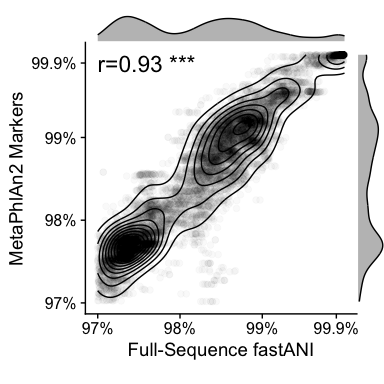

```r
plot.scatter <-
  ggscatter(data = refs %>%
  filter(!is.na(ani), !is.na(distance)) %>%
  filter(ani > min & distance > min),
  'ani', 'distance',
  color = 'black',
  fill = 'black',
  alpha = 0.025,
  xlab = 'Full-Sequence fastANI', ylab = 'MetaPhlAn2 Markers',
  ggtheme = theme_cowplot()) +
  theme(aspect.ratio = 1) +
  scale_x_continuous(labels = percent_format_signif, breaks=c(min_similarity, 0.99, 0.98, 0.97)) +
  scale_y_continuous(labels = percent_format_signif, breaks=c(min_similarity, 0.99, 0.98, 0.97)) +
  annotate('text', label = paste0('r=',
                                  refs.cor$estimate.round,
                                  ' ',
                                  refs.cor$sig),
           hjust = 0,
           x = .97, y = .999, size = 6) +
  geom_density_2d(col = 'black')

plot <-
  ggExtra::ggMarginal(plot.scatter,
                            type = 'density', color = 'black',
                            fill = 'grey75', size = 10)
plot
```

Exporting Plots

```r
output_name = 'MetaPhlAn2_FastANI.References'
ggsave(species_ridge,
       device = 'pdf', dpi = 300, width = 6, height = 8,
       filename = paste0(results_dir, fig, output_name, '.RidgePlot.pdf'))

ggsave(plot,
       device = 'pdf', dpi = 300, width = 4, height = 4,
       filename = paste0(results_dir, fig, output_name, '.CorrPlot.pdf'))
```